# Data607 Assignment 4: Tidying and Transforming Data

Anthony Josue Roman

2024-09-29

This assignment will use the following packages:

```r
library(readr)
library(RCurl)
library(stringr)
library(dplyr)
library(tidyr)
library(tidyverse)
library(ggplot2)
library(knitr)
library(kableExtra)
```

## General Overview

The goal of this assignment is to utilize untidy airport data that were on time or delayed from 5 different locations (cities) from two different airlines. The following data will also be uploaded onto my github [page](https://github.com/spacerome/Data607_Assignment_4).

## Initilization

To get the data, we will extract the data from the github file from [here](https://raw.githubusercontent.com/spacerome/Data607_Assignment_4/refs/heads/main/airline_data.csv).

```r
raw_file <- getURL("https://raw.githubusercontent.com/spacerome/Data607_Assignment_4/refs/heads/main/airline_data.csv")

csvfile <- data.frame(read.csv(text=raw_file, sep= "\t", stringsAsFactors = FALSE, check.names = FALSE))
csvfile
```

```
##     Var.1   Var.2 Los.Angeles Phoenix San.Diego San.Francisco Seattle
## 1  ALASKA on time         497     221       212           503    1841
## 2         delayed          62      12        20           102     305
## 3 AM WEST on time         694    4840       383           320     201
## 4         delayed         117     415        65           129      61
```

## Tidying the Data

```r
colnames(csvfile)[1] <- "airline"
colnames(csvfile)[2] <- "status"
csvfile
```

```
##   airline  status Los.Angeles Phoenix San.Diego San.Francisco Seattle
## 1  ALASKA on time         497     221       212           503    1841
## 2         delayed          62      12        20           102     305
## 3 AM WEST on time         694    4840       383           320     201
## 4         delayed         117     415        65           129      61
```

```r
csvfile[csvfile=="    "] <- NA
colnames(csvfile) <- gsub("\\.", " ", colnames(csvfile))
csvfile <- fill(csvfile, airline)
csvfile
```

```
##   airline  status Los Angeles Phoenix San Diego San Francisco Seattle
## 1  ALASKA on time         497     221       212           503    1841
## 2  ALASKA delayed          62      12        20           102     305
## 3 AM WEST on time         694    4840       383           320     201
## 4 AM WEST delayed         117     415        65           129      61
```

After cleaning the data then we utilize `pivot_longer` to prep `csvfile` for further data analysis.

```r
csvfile <- pivot_longer(csvfile, cols = !c(airline, status),
                        names_to = "city", values_to = "flights")
head(csvfile)
```

```
## # A tibble: 6 × 4
##   airline status  city          flights
##   <chr>   <chr>   <chr>           <int>
## 1 ALASKA  on time Los Angeles       497
## 2 ALASKA  on time Phoenix           221
## 3 ALASKA  on time San Diego         212
## 4 ALASKA  on time San Francisco     503
## 5 ALASKA  on time Seattle          1841
## 6 ALASKA  delayed Los Angeles        62
```

## Analyzing the Data

After cleaning the data we will have three variables utilized for analysis: `airlineData`, `cityData`, and `cityairlineData`.

```r
airlineData <- csvfile %>%
  group_by(airline) %>% summarise(flightFrequency = sum(flights), flightDelay = sum(ifelse(status =='delayed',flights,0)))
airlineData <- airlineData %>%
  mutate(ontimeFlights = flightFrequency - flightDelay,
         delayRate = flightDelay/ontimeFlights,
         ontimeRate = ontimeFlights/flightFrequency) %>% arrange(delayRate)
airlineData
```

```
## # A tibble: 2 × 6
##   airline flightFrequency flightDelay ontimeFlights delayRate ontimeRate
##   <chr>             <int>       <dbl>         <dbl>     <dbl>      <dbl>
## 1 AM WEST            7225         787          6438     0.122      0.891
## 2 ALASKA             3775         501          3274     0.153      0.867
```

```r
airlineData %>%
  mutate(
    delayRate = scales::percent(delayRate, accuracy = 0.01),
    ontimeRate = scales::percent(ontimeRate, accuracy = 0.01)
  ) %>%
  select(airline, delayRate, ontimeRate) %>%
  rename(
    Airline = airline,
    `Delay Rate` = delayRate,
    `Ontime Rate` = ontimeRate
  ) %>%
  kable(format = "html", caption = "Delay Rate and On-Time Rate by Airline") %>%
  kable_styling(bootstrap_options = c("striped", "hover", "condensed", "responsive"), position = "center") %>%
  row_spec(0, bold = TRUE, color = "white", background = "#4CAF50")
```

Delay Rate and On-Time Rate by Airline

| Airline | Delay Rate | Ontime Rate |
| --- | --- | --- |
| AM WEST | 12.22% | 89.11% |
| ALASKA | 15.30% | 86.73% |

From analyzing the `airlineData`, `AM WEST` has the highest ontime rate of `89.1%`, and lowest delay rate of `12.2%`, whereas `ALASKA` has a higher delay rate of `15.3%`, but lower ontime rate of `86.7%`.

```r
cityData <- csvfile %>%
  group_by(city) %>% summarise(flightFrequency = sum(flights), flightDelay = sum(ifelse(status =='delayed',flights,0)))
cityData <- cityData %>%
  mutate(ontimeFlights = flightFrequency - flightDelay,
         delayRate = flightDelay/ontimeFlights,
         ontimeRate = ontimeFlights/flightFrequency) %>% arrange(delayRate)
cityData
```

```
## # A tibble: 5 × 6
##   city          flightFrequency flightDelay ontimeFlights delayRate ontimeRate
##   <chr>                   <int>       <dbl>         <dbl>     <dbl>      <dbl>
## 1 Phoenix                  5488         427          5061    0.0844      0.922
## 2 San Diego                 680          85           595    0.143       0.875
## 3 Los Angeles              1370         179          1191    0.150       0.869
## 4 Seattle                  2408         366          2042    0.179       0.848
## 5 San Francisco            1054         231           823    0.281       0.781
```

From analyzing the `cityData`, Phoenix has the highest ontime Rate of `92.2%`, and lowest delay rate of `8.44%`. San Francisco has the highest delay rate of `28.1%` and its ontime rate is `78.1%`.

```r
cityairlineData <- csvfile %>%
  group_by(city, airline) %>%
  summarise(flightFrequency = sum(flights, na.rm = TRUE),
            flightDelay = sum(ifelse(status == 'delayed', flights, 0), na.rm = TRUE)) %>%
  mutate(ontimeFlights = flightFrequency - flightDelay,
         delayRate = flightDelay / flightFrequency, ontimeRate = ontimeFlights/flightFrequency) %>%
  ungroup()
cityairlineData
```

```
## # A tibble: 10 × 7
##    city   airline flightFrequency flightDelay ontimeFlights delayRate ontimeRate
##    <chr>  <chr>             <int>       <dbl>         <dbl>     <dbl>      <dbl>
##  1 Los A… ALASKA              559          62           497    0.111       0.889
##  2 Los A… AM WEST             811         117           694    0.144       0.856
##  3 Phoen… ALASKA              233          12           221    0.0515      0.948
##  4 Phoen… AM WEST            5255         415          4840    0.0790      0.921
##  5 San D… ALASKA              232          20           212    0.0862      0.914
##  6 San D… AM WEST             448          65           383    0.145       0.855
##  7 San F… ALASKA              605         102           503    0.169       0.831
##  8 San F… AM WEST             449         129           320    0.287       0.713
##  9 Seatt… ALASKA             2146         305          1841    0.142       0.858
## 10 Seatt… AM WEST             262          61           201    0.233       0.767
```

```r
cityairlineData %>%
  mutate(
    delayRate = scales::percent(delayRate, accuracy = 0.01),
    ontimeRate = scales::percent(ontimeRate, accuracy = 0.01)
  ) %>%
  select(city, airline, delayRate, ontimeRate) %>%
  rename(
    City = city,
    Airline = airline,
    `Delay Rate` = delayRate,
    `Ontime Rate` = ontimeRate
  ) %>%
  kable(format = "html", caption = "Delay Rate and On-Time Rate by City and Airline") %>%
  kable_styling(bootstrap_options = c("striped", "hover", "condensed", "responsive"), position = "center") %>%
  row_spec(0, bold = TRUE, color = "white", background = "#4CAF50")
```

Delay Rate and On-Time Rate by City and Airline

| City | Airline | Delay Rate | Ontime Rate |
| --- | --- | --- | --- |
| Los Angeles | ALASKA | 11.09% | 88.91% |
| Los Angeles | AM WEST | 14.43% | 85.57% |
| Phoenix | ALASKA | 5.15% | 94.85% |
| Phoenix | AM WEST | 7.90% | 92.10% |
| San Diego | ALASKA | 8.62% | 91.38% |
| San Diego | AM WEST | 14.51% | 85.49% |
| San Francisco | ALASKA | 16.86% | 83.14% |
| San Francisco | AM WEST | 28.73% | 71.27% |
| Seattle | ALASKA | 14.21% | 85.79% |
| Seattle | AM WEST | 23.28% | 76.72% |

## Visualization

The following code blocks below will be visualizations from the data.

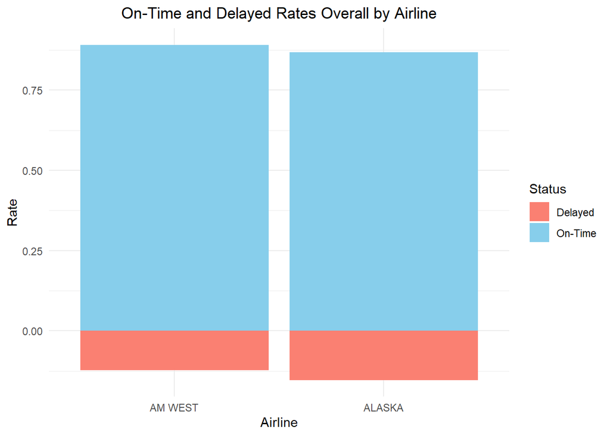

```r
ggplot(airlineData, aes(x = reorder(airline, -flightFrequency))) +
  geom_bar(aes(y = ontimeRate, fill = "On-Time"), stat = "identity") +
  geom_bar(aes(y = -delayRate, fill = "Delayed"), stat = "identity") +
  labs(title = "On-Time and Delayed Rates Overall by Airline", x = "Airline", y = "Rate", fill = "Status") +
  scale_fill_manual(values = c("On-Time" = "skyblue", "Delayed" = "salmon")) +
  theme_minimal() +
  theme(plot.title = element_text(hjust = 0.5))
```

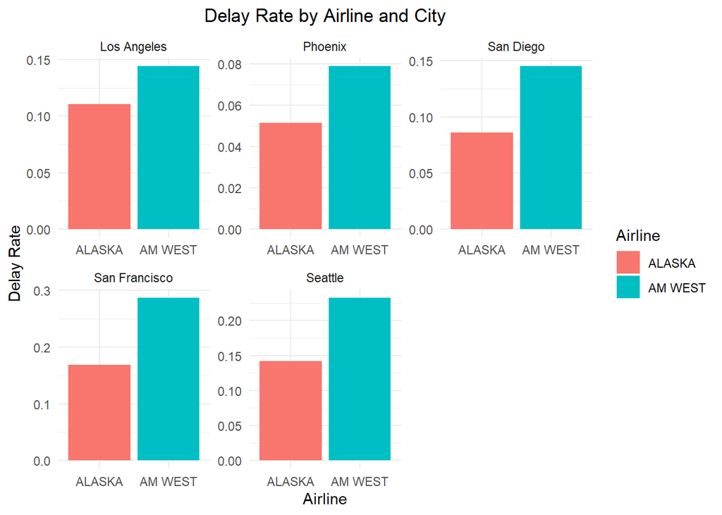

```r
ggplot(cityairlineData, aes(x = airline, y = delayRate, fill = airline)) +
  geom_bar(stat = "identity", position = position_dodge()) +
  labs(title = "Delay Rate by Airline and City",
       x = "Airline", y = "Delay Rate") +
  facet_wrap(~ city, scales = "free") +
  theme_minimal() +
  theme(plot.title = element_text(hjust = 0.5)) +
  guides(fill = guide_legend(title = "Airline"))
```

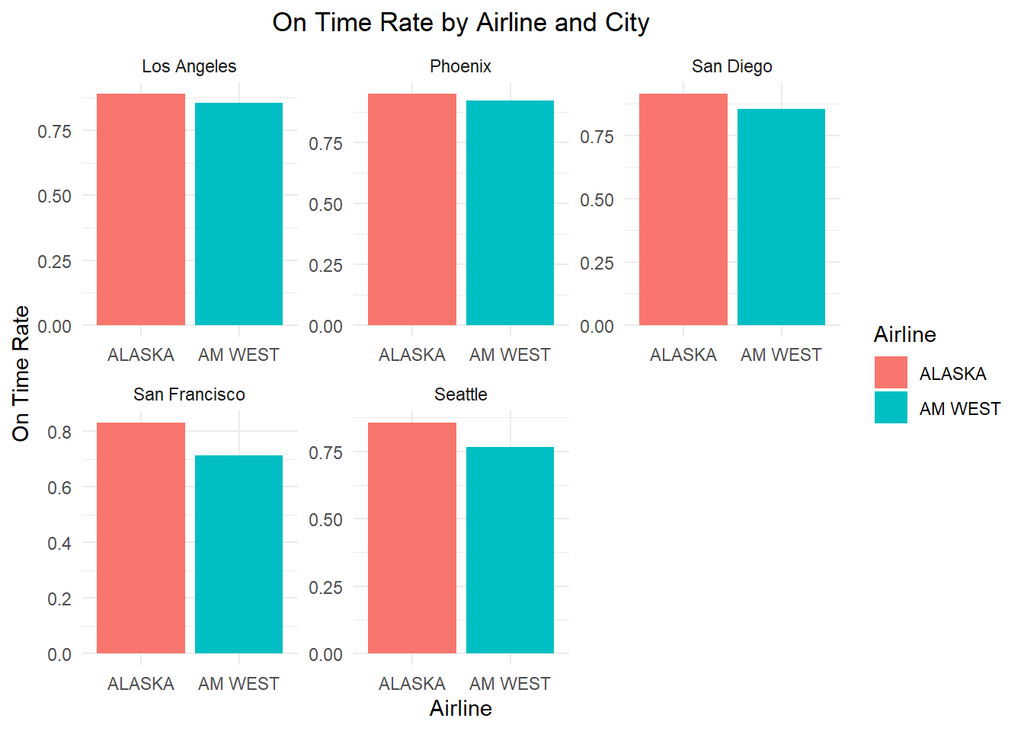

```r
ggplot(cityairlineData, aes(x = airline, y = ontimeRate, fill = airline)) +
  geom_bar(stat = "identity", position = position_dodge()) +
  labs(title = "On Time Rate by Airline and City",
       x = "Airline", y = "On Time Rate") +
  facet_wrap(~ city, scales = "free") +
  theme_minimal() +
  theme(plot.title = element_text(hjust = 0.5)) +
  guides(fill = guide_legend(title = "Airline"))
```

Over here this bar plot shows a pretty tight on-time rate between all five cities, with `ALASKA` being slightly higher than `AM WEST`.

## CSV File Output

Outputs a csv file to replicate anaylsis:

```r
write.csv(csvfile,"airline_data.csv")
```

## Conclusion

Overall, from the data used for this assignment, `AM WEST` has a higher delay rate in all cities, **but** overall, `ALASKA` has a higher delay rate overall than `AM WEST`.

I believe if I had more data, such as more cities for each airline, or maybe more airlines, we can get a general understanding on what may be causing the delays for each city. I believe there is also an r library for flights that can be utilized to get a general understanding on why there are flights not arriving on time for San Francisco. I do believe if we include factors such as air traffic, weather, and other uncontrollable factors, this will give us a general understanding on *why* this is occurring.